# scATAC-pro Downstream analysis in R

3 June 2020

# 1 Introduction

scATAC-pro generates results in plain texts, tables and .rds objects. This tutorial will access original results module by module, which was done by running command lines. Also, we show how some modules can be re-run using different options or parameters. We will use scATAC-pro outputs of the PBMC 10x Genomics data as in the manuscript, except for the integrate module, where output from another study was used for illustration purpose.

## 1.1 Set up parameters, scATAC-pro output dir and source raw codes

```r
library(data.table)
library(magrittr)
library(ggplot2)
library(Seurat)

PEAK_CALLER = 'COMBINED'
CELL_CALLER = 'FILTER'
output_dir = '/mnt/isilon/tan_lab/yuw1/run_scATAC-pro/PBMC10k/output/'
down_dir = paste0(output_dir, 'downstream_analysis/', PEAK_CALLER, '/',
                  CELL_CALLER, '/')
devtools::source_url("https://github.com/wbaopaul/scATAC-pro/blob/master/scripts/src/dsAnalysis_utilities.R?raw=TRUE")
```

# 2 Access or re-run Downstream Analysis

## 2.1 Access original results

### 2.1.1 Access filtered peak-by-cell count matrix

```r
mtx_path = paste0(output_dir, 'filtered_matrix/', PEAK_CALLER, '/', CELL_CALLER, '/matrix.mtx')
mtx = read_mtx_scATACpro(mtx_path)
rownames(mtx)[1:10]
```

```
##  [1] "chr1-100028750-100029265" "chr1-100037792-100039050"
##  [3] "chr1-100046917-100047167" "chr1-100047455-100047597"
##  [5] "chr1-100064941-100065019" "chr1-1000654-1000992"
##  [7] "chr1-100065422-100065540" "chr1-100132556-100133436"
##  [9] "chr1-100152259-100152542" "chr1-100184588-100184845"
```

```r
colnames(mtx)[1:10]
```

```
##  [1] "AAACGAAAGACACGGT" "AAACGAAAGAGGTGGG" "AAACGAAAGCACGTAG" "AAACGAAAGCGCCTAC"
##  [5] "AAACGAAAGCTTTCCC" "AAACGAAAGGCGTCCT" "AAACGAAAGGCTTTAC" "AAACGAAAGTGATATG"
##  [9] "AAACGAACAAACGACG" "AAACGAACAATTGCCA"
```

### 2.1.2 Clustering

Clustering result was saved in .rds file as *seurat_obj.rds* and clustering label as one of the metadata

```r
seurat_obj = readRDS(paste0(down_dir, 'seurat_obj.rds'))

## cluster label was saved in metadata active_clusters
table(seurat_obj$active_clusters)
```

```
##
##    0    1    2    3    4    5    6    7    8    9
## 2139 1877  823  622  395  362  251  146  129   39
```

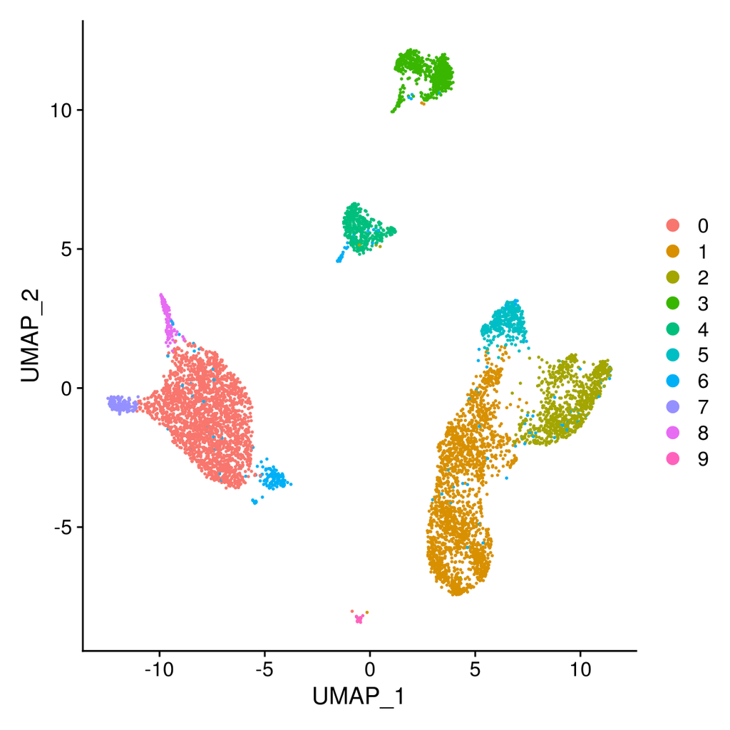

```r
## plot umap
DimPlot(seurat_obj, reduction = 'umap')
```

### 2.1.3 GO Analysis

The GO term enrichment result was saved in a .xlsx file.

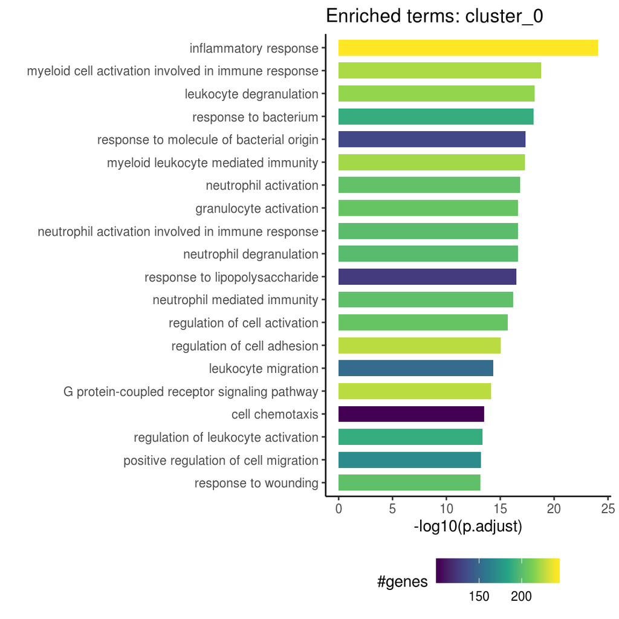

```r
library(xlsx)
group1 = 'one'
group2 = 'rest'
go_file = paste0(down_dir, 'enrichedGO_differential_accessible_features_', group1, '_vs_', group2, '.xlsx')

# get enriched terms for cluster0 for example and show top 20 terms
go_res = xlsx::read.xlsx(go_file, sheetName = 'cluster0')

go_res = data.table(go_res)
go_res[, 'score' := -log10(p.adjust)]
go_res = go_res[order(-score), ]
ngo = min(20, nrow(go_res))
go_res = go_res[1:ngo, ]
go_res = go_res[order(score), ]
go_res$Description = factor(go_res$Description, levels = go_res$Description)

p_go <- ggplot(go_res, aes(y = score, x = Description, fill = Count)) +
  geom_bar(width = 0.7, stat = 'identity') +
  ggtitle("Enriched terms: cluster_0") + theme_classic() +
  theme(legend.position = 'bottom', legend.direction = "horizontal") +
  coord_flip()  +  scale_fill_continuous(name = "#genes", type = "viridis") +
  xlab('') + ylab('-log10(p.adjust)')

p_go
```

### 2.1.4 TF motif enrichment analysis

The analysis was done through *chromVAR* R package.

- A chromVAR object was saved in .rds format (by which users can access the deviation score and the z score per cell) along with a table for enriched TFs per cluster (top 10 per cluster by default)

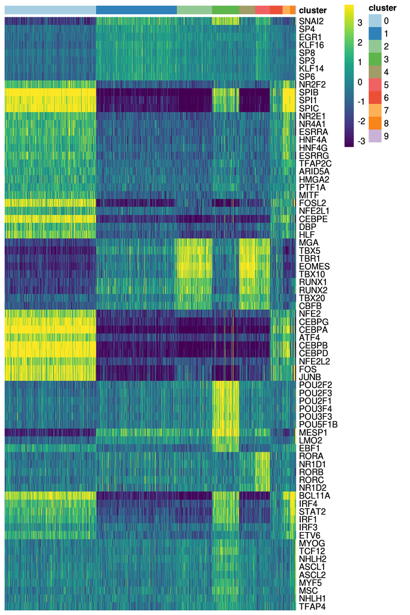

```r
library(RColorBrewer)
library(viridis)
library(pheatmap)
GENOME_NAME = 'hg38'


metaData = seurat_obj@meta.data

chromVar.obj = readRDS(paste0(down_dir, '/chromVar_obj.rds'))
diff_tf_enrich_file = paste0(down_dir, '/differential_TF_motif_enriched_in_clusters.txt')

da.res = fread( paste0(down_dir, '/differential_TF_motif_enriched_in_clusters.txt'))

## plot enriched TFs in heatmap
sele.tfs = da.res$feature
zscores = deviationScores(chromVar.obj)
sele.zscores = zscores[sele.tfs, ]

## change rowname of zscores (tf name) to be readable
sele.zscores <- readable_tf(sele.zscores, GENOME_NAME)


metaData$active_clusters = as.character(metaData$active_clusters)


sele.zscores = sele.zscores[!duplicated(sele.zscores), ]


bc_clusters = data.table('barcode' = rownames(metaData),
                         'cluster' = metaData$active_clusters)

plot_enrich_tf(sele.zscores, bc_clusters)
```

- You can redo differential TF enrichment analysis, for example, you can output different number of TFs for each cluster:

```r
da.res = do_DA_motif(deviations(chromVar.obj), bc_clusters,
                       topn = 5)

sele.zscores = zscores[da.res$feature, ]

## change rowname of zscores (tf name) to be readable
sele.zscores <- readable_tf(sele.zscores, GENOME_NAME)

plot_enrich_tf(sele.zscores, bc_clusters)
```

### 2.1.5 TF footprinting analysis

The differential bound TFs were saved in a table of plain text format

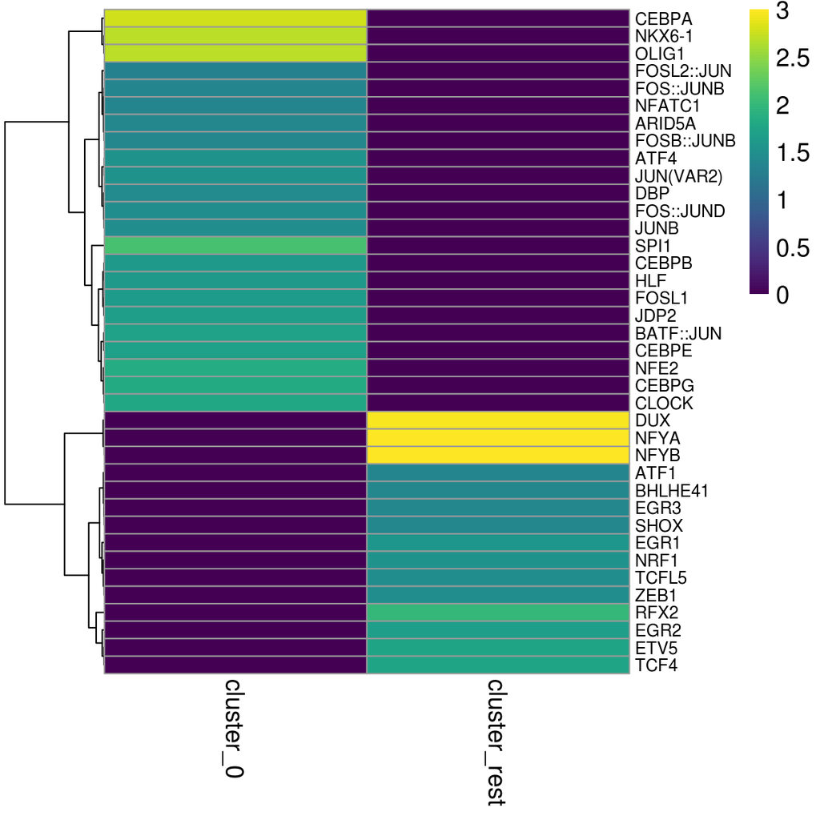

```r
group1_fp = '0'
group2_fp = 'rest'
footprint_stats.file = paste0(down_dir, '/differential_TF_footprint_',
                              group1_fp, '_vs_', group2_fp, '.txt')
if(file.exists(footprint_stats.file)){

  footprint_out = fread(footprint_stats.file)
  if(length(unique(footprint_out$motif)) > 100){
  footprint_out[, 'N' := .N, by = higher_in_cluster]
  cls = unique(footprint_out[N > 10]$higher_in_cluster)
  if(length(cls) >= 1){
    res0 = NULL
    for(cl0 in cls){
      tmp = footprint_out[higher_in_cluster == cl0]
      tmp = tmp[order(P_values)][1:10, ]
      res0 = rbind(res0, tmp)
    }
    footprint_out = rbind(footprint_out[N < 10], res0)
  }
}

  mm = reshape2::acast(motif ~ higher_in_cluster, data = footprint_out,
                       value.var = "P_values")
  mm = -log10(mm)
  mm[is.na(mm)] = 0
  cn = colnames(mm)
  cn.new = sapply(cn, function(x) gsub('_higher', '', x))
  colnames(mm) = cn.new
  mm[mm > 3] = 3
  pheatmap(mm, cluster_cols = F, fontsize = 13, fontsize_row = 9,
                           color = viridis::viridis(100))



}
```

### 2.1.6 Access cicero Cis interactions

The cis-interactions were saved in a plain text file. Here we gonna read the interactions and plot the cis-loop within an interested region. You can change parameter *Cicero_Plot_Region* below to your interested genomic region:

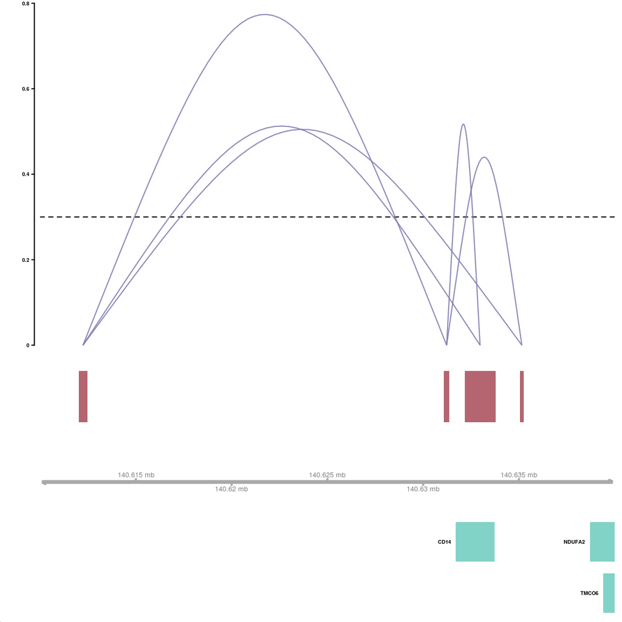

```r
library(cicero)
cicero_conn.file = paste0(down_dir, '/cicero_interactions.txt')
Cicero_Plot_Region = 'chr5:140610000-140640000'
if(file.exists(cicero_conn.file)){
  conns = fread(cicero_conn.file)
  conns = data.frame(conns)
  temp <- tempfile()
  if(grepl(GENOME_NAME, pattern = 'mm10', ignore.case = T)) {
    download.file('ftp://ftp.ensembl.org/pub/release-95/gtf/mus_musculus/Mus_musculus.GRCm38.95.gtf.gz', temp)
  }

  if(grepl(GENOME_NAME, pattern = 'mm9', ignore.case = T)) {
    download.file('ftp://ftp.ensembl.org/pub/release-67/gtf/mus_musculus/Mus_musculus.NCBIM37.67.gtf.gz', temp)
  }

  if(grepl(GENOME_NAME, pattern = 'hg38', ignore.case = T)) {
    download.file('ftp://ftp.ensembl.org/pub/release-95/gtf/homo_sapiens/Homo_sapiens.GRCh38.95.gtf.gz', temp)
  }

  if(grepl(GENOME_NAME, pattern = 'hg19', ignore.case = T)) {
    download.file('ftp://ftp.ensembl.org/pub/release-67/gtf/homo_sapiens/Homo_sapiens.GRCh37.67.gtf.gz', temp)
  }

  gene_anno <- rtracklayer::readGFF(temp)
  unlink(temp)

  # rename some columns to match requirements
  gene_anno$chromosome <- paste0("chr", gene_anno$seqid)
  gene_anno$gene <- gene_anno$gene_id
  gene_anno$transcript <- gene_anno$transcript_id
  gene_anno$symbol <- gene_anno$gene_name
  gene_anno = subset(gene_anno, select = c(chromosome, start, end, strand,
                                           transcript, gene, symbol))
  gene_anno = gene_anno[complete.cases(gene_anno), ]

  chr0 = unlist(strsplit(Cicero_Plot_Region, ':'))[1] ## chr5:140610000-140640000
  region0 = unlist(strsplit(Cicero_Plot_Region, ':'))[2]
  start0 = as.integer(unlist(strsplit(region0, '-'))[1])
  end0 = as.integer(unlist(strsplit(region0, '-'))[2])


  cicero::plot_connections(conns, chr0, start0, end0,
                   gene_model = gene_anno,
                   coaccess_cutoff = .3,
                   connection_width = 1,
                   collapseTranscripts = "longest",
                   viewpoint_alpha = 0)

}
```

### 2.1.7 Integration

- For this session, an integrated object from the other study was used for illustration purpose
- Suppose we have an integrated .rds object outputted from *integrate* module with parameter Integrate_By set as ‘VFACS’ (other options are ‘seurat’, ‘pool’, or ‘harmony’)

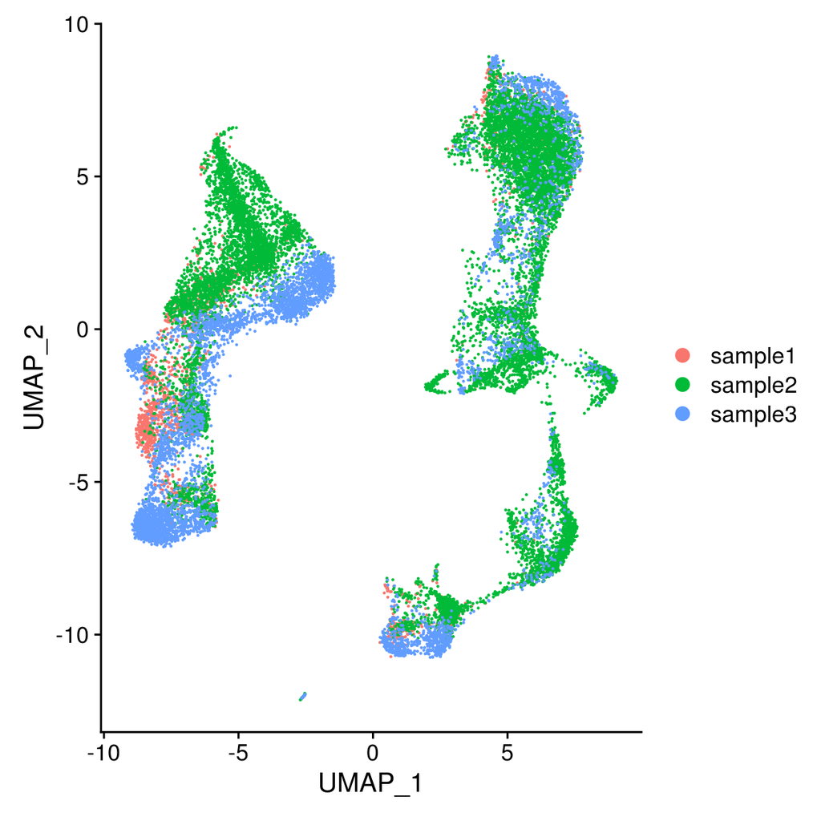

```r
integrated_obj <- readRDS(paste0(output_dir, 'integrated/seurat_obj_VFACS.rds'))

DimPlot(integrated_obj, group.by = 'sample')
```

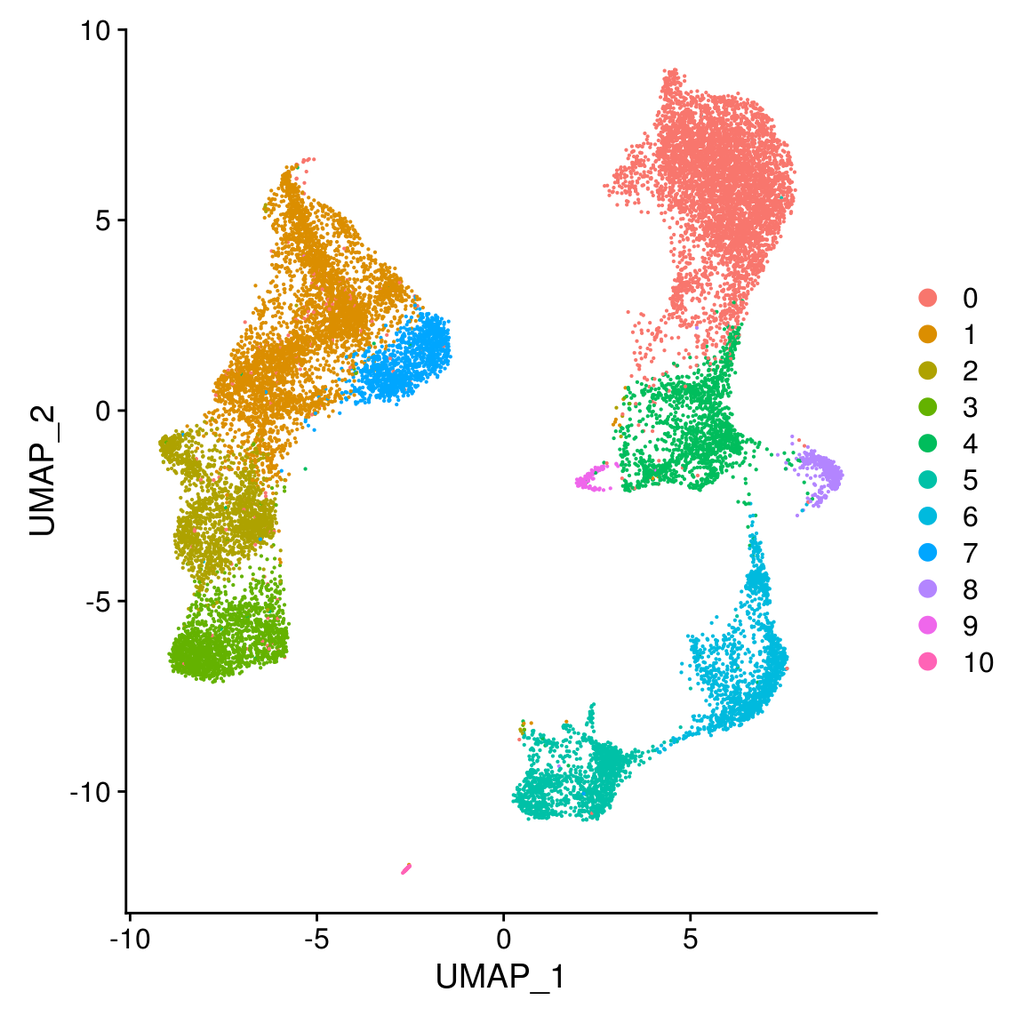

```r
DimPlot(integrated_obj, group.by = 'active_clusters')
```

## 2.2 Reanalyze data alternatively

### 2.2.1 Reclustering using seurat implemented louvain algorithm with different parameters

You can also re-cluster the cells with different number of reduced dimension or resolutions, for example

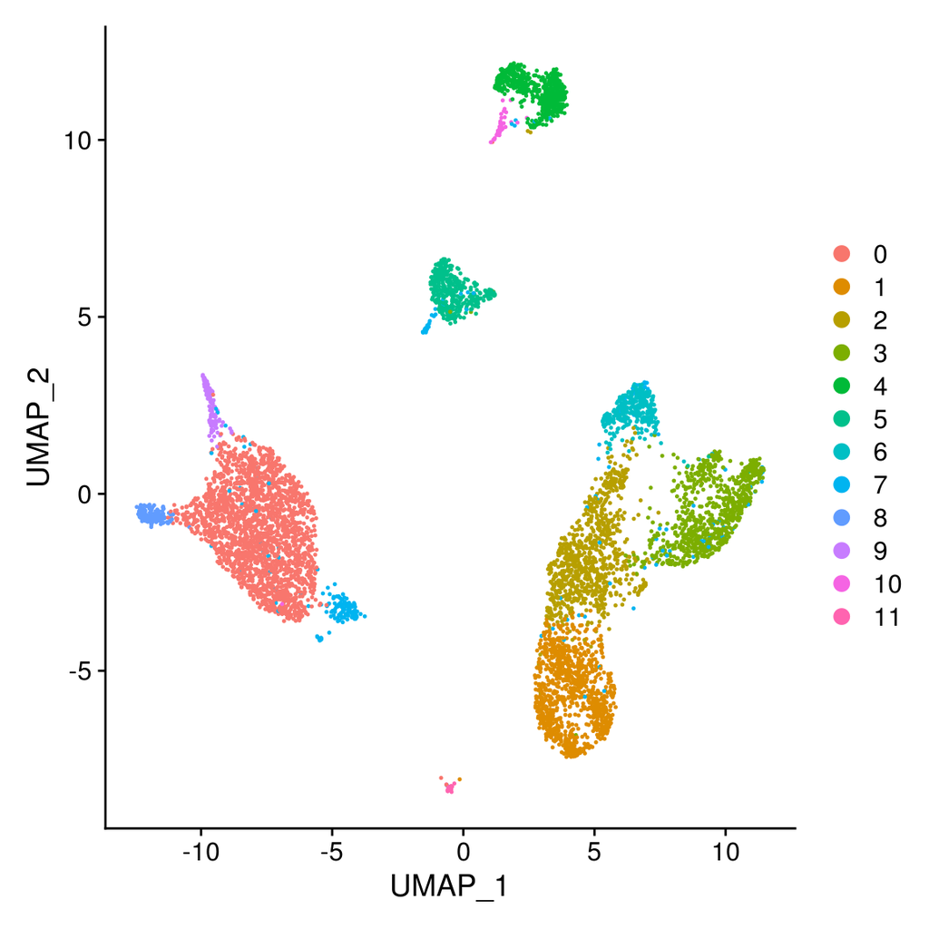

```r
seurat_obj <- RunPCA(seurat_obj, npcs = 20)
seurat_obj <- FindNeighbors(seurat_obj, reduction = 'pca', dims = 1:20)
seurat_obj <- FindClusters(seurat_obj, resolution = 0.4)
## Modularity Optimizer version 1.3.0 by Ludo Waltman and Nees Jan van Eck
##
## Number of nodes: 6783
## Number of edges: 257994
##
## Running Louvain algorithm...
## Maximum modularity in 10 random starts: 0.9244
## Number of communities: 12
## Elapsed time: 0 seconds
seurat_obj$active_clusters = seurat_obj$seurat_clusters
DimPlot(seurat_obj)
```

If you want to cluster the data into k clusters, 8 for instance, we provided a query function which helps you looking for the corresponding resolution parameter.

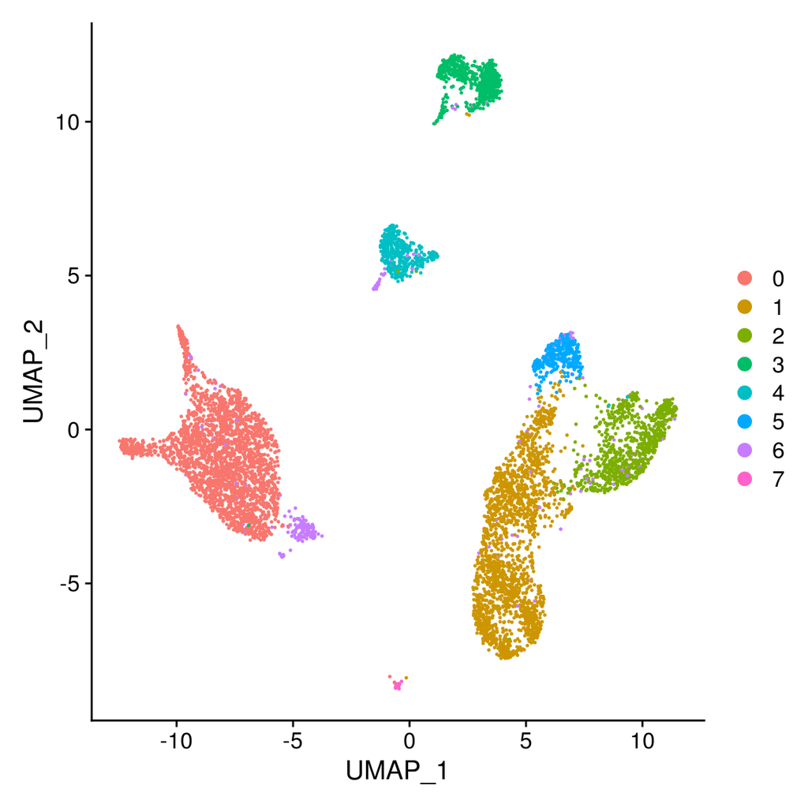

```r
resl <- queryResolution4Seurat(seurat_obj, k = 8, reduction = 'pca',
                               npc = 20, min_resl = 0.1, max_resl = 1,
                               max_iter = 15)
## Modularity Optimizer version 1.3.0 by Ludo Waltman and Nees Jan van Eck
##
## Number of nodes: 6783
## Number of edges: 257994
##
## Running Louvain algorithm...
## Maximum modularity in 10 random starts: 0.9719
## Number of communities: 8
## Elapsed time: 0 seconds
## Modularity Optimizer version 1.3.0 by Ludo Waltman and Nees Jan van Eck
##
## Number of nodes: 6783
## Number of edges: 257994
##
## Running Louvain algorithm...
## Maximum modularity in 10 random starts: 0.8580
## Number of communities: 18
## Elapsed time: 0 seconds
seurat_obj <- FindClusters(seurat_obj, resolution = resl)
## Modularity Optimizer version 1.3.0 by Ludo Waltman and Nees Jan van Eck
##
## Number of nodes: 6783
## Number of edges: 257994
##
## Running Louvain algorithm...
## Maximum modularity in 10 random starts: 0.9719
## Number of communities: 8
## Elapsed time: 1 seconds
seurat_obj$active_clusters = seurat_obj$seurat_clusters
DimPlot(seurat_obj)
```

### 2.2.2 Reclustering using different methods

You can recluster the data by different methods, such as kmeans ( *generalCluster* function), cisTopic (*run_cisTopic*), scABC (*run_scABC*), SCRAT (*run_scrat*) and chromVAR (*run_chromVAR*).

```r
## further filter matrix
mtx <- filterMat(mtx, minFrac_in_cell = 0.01, min_depth = 1000, max_depth = 50000)

## create a new seurat obj for visualize and other analysis
seurat_obj.new <- runSeurat_Atac(mtx, npc = 20, norm_by = 'tf-idf',
                   top_variable_features = 5000, reg.var = 'nCount_ATAC')

seurat_obj.new <- RunUMAP(seurat_obj.new, dims = 1:20)
```

#### 2.2.2.1 SCRAT

```r
cl.labels <- run_scrat(mtx, reduction = 'pca', max_pc = 20, k = 8)
seurat_obj.new$active_clusters = cl.labels
DimPlot(seurat_obj.new, group.by = 'active_clusters')
```

#### 2.2.2.2 cisTopic

This method will take a while.

```r
cisTopic.obj <- run_cisTopic(mtx, nCores = 5, topic = c(10, 20, 30, 50, 100),
                          frac_in_cell = 0.05)

## select the best model and lda as a new dimension reduction the seurat obj
sele.model <- cisTopic::selectModel(cisTopic.obj, select = nREDUCTION,
                               keepBinaryMatrix = F, keepModels = F)
cell_topic <- t(modelMatSelection(sele.model, 'cell', 'Probability'))
cl.labels = generalCluster(cell_topic, method = 'hclust', k = 8)

seurat_obj.new[['lda']] <- CreateDimReducObject(embeddings = cell_topic,
                                              key = '_Topic', assay = DefaultAssay(seurat_obj.new))


## You can run umap or clustering on lda by specifying reduction='lda'
seurat_obj.new <- RunUMAP(seurat_obj.new, dims = 1:ncol(cell_topic), reduction = 'lda')

seurat_obj.new <- FindNeighbors(seurat_obj.new, reduction = 'lda', dims = 1:ncol(cell_topic))
seurat_obj.new <- FindClusters(seurat_obj.new, resolution = 0.4)
seurat_obj.new$active_clusters = seurat_obj.new$seurat_cluster
DimPlot(seurat_obj.new)
```

#### 2.2.2.3 kmeans (on PCs)

```r
cl.labels <- generalCluster(seurat_obj.new@reductions$pca@cell.embeddings,
                            method = 'kmeans', k = 8)
```

#### 2.2.2.4 chromVAR

```r
## if you have already run motif analysis, chromvar obj was saved and
chromVar.obj <- readRDS(paste0(down_dir, '/chromVar_obj.rds'))

## otherwise
#chromVar.obj <- run_chromVAR(mtx, genomeName = 'BSgenome.Hsapiens.UCSC.hg38', ncore = 4)

zscore = chromVar.obj@assays@data$z
zscore = dev.score[, colnames(dev.score) %in% colnames(mtx)]

pca_coords = doDimReduction4mat(zscore, max_pc = 20)[[1]]

cl.labels = cutree(hclust(dist(pca_coords)), k = 8)
```

#### 2.2.2.5 scABC

This method is also pretty slow.

```r
cl.labels <- run_scABC(mtx, k = 8)
```

#### 2.2.2.6 LSI

This is the original LSI method (the first PC was discarded), and you can specify different number of PCs and filter peaks

```r
cl.labels <- run_LSI(mtx, ncell.peak = 150, max_pc = 10, k = 8)
```

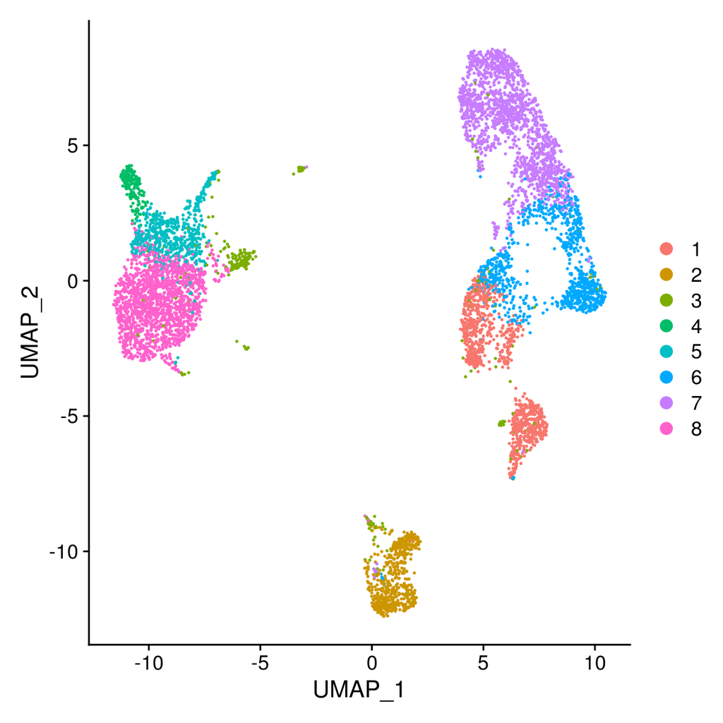

```r
seurat_obj.new$active_clusters = cl.labels

DimPlot(seurat_obj.new, group.by = 'active_clusters')
```